# homework_2_armstrong_lionel

Lionel Armstrong

February 11, 2018

**3.2.4 Exercises**

*1.Run ggplot(data = mpg) . What do you see?*

**ANSWER:**

Creates a coordinate system that you can add layers to. The first argument of ggplot() is the dataset to use in the graph. So ggplot(data = mpg) creates an empty graph.

```r
ggplot(data=mpg)
```

*2.How many rows are in mpg ? How many columns?*

**ANSWER:**  
Data set mpg has 234 rows and 11 columns. See glimpse below.

```r
glimpse(mpg)
```

*3.What does the drv variable describe?*

**ANSWER:**

The drv variable describes the wheel drive be it f for front wheel drive or r for rear wheel drive or 4 for 4wd

```r
?mpg
```

*4.Make a scatterplot of hwy vs cyl.*

**ANSWER:**

```r
ggplot(data = mpg) +
  geom_point(mapping = aes(x = hwy, y = cyl))
```

*5.What happens if you make a scatterplot of class vs drv ? Why is the plot not useful?*

**ANSWER:**

The scatterplot displays a point for every occurrence of the intersection of the drv values and the class values. The hidden summary data being the count of the number of intersections isn’t shown on the scatterplot.

```r
ggplot(data = mpg) +
  geom_point(mapping = aes(x = class, y = drv))
```

**3.3.1 Exercises**

*1.What’s gone wrong with this code? Why are the points not blue?*

ggplot(data = mpg) + geom_point(mapping = aes(x = displ, y = hwy, color = “blue”))

**ANSWER:**

In the aesthetic mapping color is coded to add a third variable to a two dimensional scatterplot. Quotes are not used when specifying a variable.

The correct coding is as follows:

```r
ggplot(data = mpg) +
  geom_point(mapping = aes(x = displ, y = hwy, color = class))
```

To set the dots blue, color as an aesthetic is coded as follows:

```r
ggplot(data = mpg) +
  geom_point(mapping = aes(x = displ, y = hwy), color = "blue")
```

*2.Which variables in mpg are categorical? Which variables are continuous? (Hint: type ?mpg to read the documentation for the dataset). How can you see this information when you run mpg ?*

**ANSWER:**

```r
mpg
```

| manufacturer | model | displ | year | cyl | trans | drv | cty | hwy | fl | class |
| --- | --- | --- | --- | --- | --- | --- | --- | --- | --- | --- |
| audi | a4 | 1.8 | 1999 | 4 | auto(l5) | f | 18 | 29 | p | compact |
| audi | a4 | 1.8 | 1999 | 4 | manual(m5) | f | 21 | 29 | p | compact |
| audi | a4 | 2.0 | 2008 | 4 | manual(m6) | f | 20 | 31 | p | compact |
| audi | a4 | 2.0 | 2008 | 4 | auto(av) | f | 21 | 30 | p | compact |
| audi | a4 | 2.8 | 1999 | 6 | auto(l5) | f | 16 | 26 | p | compact |
| audi | a4 | 2.8 | 1999 | 6 | manual(m5) | f | 18 | 26 | p | compact |
| audi | a4 | 3.1 | 2008 | 6 | auto(av) | f | 18 | 27 | p | compact |
| audi | a4 quattro | 1.8 | 1999 | 4 | manual(m5) | 4 | 18 | 26 | p | compact |
| audi | a4 quattro | 1.8 | 1999 | 4 | auto(l5) | 4 | 16 | 25 | p | compact |
| audi | a4 quattro | 2.0 | 2008 | 4 | manual(m6) | 4 | 20 | 28 | p | compact |

[output cut: 224 more lines]

*3.Map a continuous variable to color , size , and shape . How do these aesthetics behave differently for categorical vs. continuous variables?*

**ANSWER:**

The color aesthetic for a continuous variable is displayed as a gradation scale based on the variables value.

The color aesthetic for a categorical variable is displayed as a different color for each value/factor.

A continuous variable can’t be mapped to the shape aesthetic..

The shape aesthetic for a categorical variable is displayed as a different shapes for each value/factor.

The size aesthetic for a continuous variable is displayed as relative size of the plot points to the value of the variable.

The size aesthetic for a categorical variable isn’t advise. Showing each factor as different sizes doesn’t add to the story being told.

```r
ggplot(data = mpg) +
  geom_point(mapping = aes(x = displ, y = hwy, color = class))
ggplot(data = mpg) +
  geom_point(mapping = aes(x = displ, y = hwy, color = cyl))
```

```r
ggplot(data = mpg) +
  geom_point(mapping = aes(x = displ, y = hwy, shape = drv))
ggplot(data = mpg) +
  geom_point(mapping = aes(x = displ, y = hwy, shape = cty))
```

```r
ggplot(data = mpg) +
  geom_point(mapping = aes(x = displ, y = hwy, size = class))
ggplot(data = mpg) +
  geom_point(mapping = aes(x = displ, y = hwy, size = cty))
```

*4.What happens if you map the same variable to multiple aesthetics?*

**ANSWER:**

When multiple aesthete tics are applied to the same variable the size, color, and alpha aesthetic are applied. The shape aesthetic can’t be applied to a continuous variable. The size aesthetic isn’t advise for use with a categorical variable.

```r
ggplot(data = mpg) +
  geom_point(mapping = aes(x = displ, y = hwy, color = hwy, size=hwy, alpha=hwy))
```

```r
ggplot(data = mpg) +
  geom_point(mapping = aes(x = drv, y = hwy, color = drv, size=drv,shape=drv, alpha=drv))
```

*5.What does the stroke aesthetic do? What shapes does it work with? (Hint: use ?geom_point)*

**ANSWER:**

The stroke aesthetic works with points. The stroke aesthetic is used to change the boarder size of points.

```r
ggplot(data = mpg) +
  geom_point(mapping = aes(x = displ, y = hwy, stroke = 5))
```

```r
ggplot(data = mpg) +
  geom_point(mapping = aes(x = displ, y = hwy))
```

*6.What happens if you map an aesthetic to something other than a variable name, like aes(colour = displ < 5)?*

**ANSWER:**

The color aesthetic is applied to condition being true or false, that is, all points for which the condition is true are set to one color and the false points are set to another color.

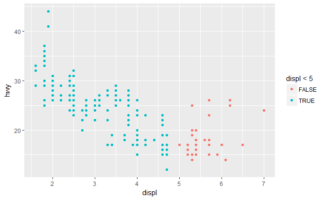

```r
ggplot(data = mpg) +
  geom_point(mapping = aes(x = displ, y = hwy, color = displ <5))
```

*4.Take the first faceted plot in this section:*

*What are the advantages to using faceting instead of the colour aesthetic? What are the disadvantages? How might the balance change if you had a larger dataset?*

**ANSWER:**

The color aesthetic has the disadvantage of not being a viable solution for presentation to color blind people and well as being difficult to differentiate color shade variations, Faceting has the advantage of presenting a focused view of the third variable.

```r
ggplot(data = mpg) +
  geom_point(mapping = aes(x = displ, y = hwy)) +
  facet_wrap(~ class, nrow = 2)
```

*5.Read ?facet_wrap . What does nrow do? What does ncol do? What other options control the layout of the individual panels? Why doesn’t facet_grid() have nrow and ncol argument?*

**ANSWER:**

nrow controls the number of panel rows the plot charts are displayed ncol controls the number of panel columns the plot charts are displayed

The facet_grid() doesn’t have nrow and ncol arguments because the matrix of panels is defined by the faceting variables.

```r
?facet_wrap
```

**3.6.1 Exercises**

*1.What geom would you use to draw a line chart? A boxplot? A histogram? An area chart?*

**ANSWER:**

Use geom_line to draw a line chart. Use geom_area to draw a area chart. Use geom_boxplot to draw a boxplot. Use geom_histogram to draw histogram.

```r
ggplot(data = mpg) +
  geom_line(mapping = aes(x = displ, y = hwy))
```

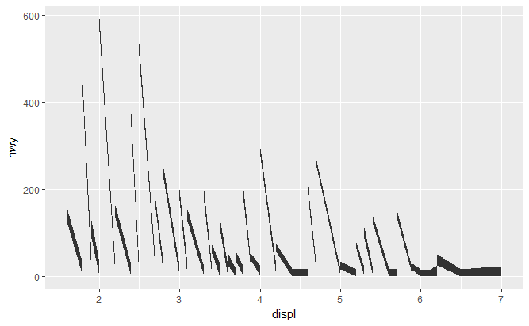

```r
ggplot(data = mpg) +
  geom_area(mapping = aes(x = displ, y = hwy))
```

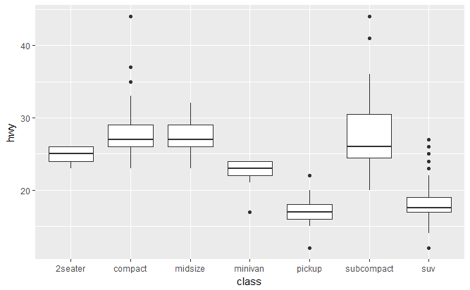

```r
ggplot(data = mpg) +
  geom_boxplot(mapping = aes(x = class, y = hwy))
```

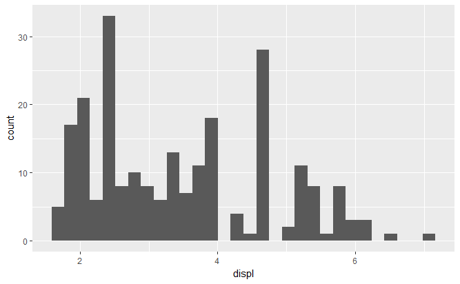

```r
ggplot(data = mpg) +
  geom_histogram(mapping = aes(x = displ))
```

*2.Run this code in your head and predict what the output will look like. Then, run the code in R and check your predictions.*

ggplot(data = mpg, mapping = aes(x = displ, y = hwy, color = drv)) + geom_point() + geom_smooth(se = FALSE)

**ANSWER:**

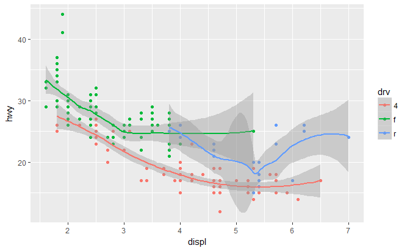

```r
ggplot(data = mpg, mapping = aes(x = displ, y = hwy, color = drv)) +
  geom_point() +
  geom_smooth()
```

*3.What does show.legend = FALSE do? What happens if you remove it?* *Why do you think I used it earlier in the chapter?*

**ANSWER:**

The show.legend argument controls the display of the legend associated with a categorical variable. Setting the argument equal FALSE removes the legend from the graph.

The show.legend explicit suppression of the legend was shown in contrast with the group aesthetics lack of providing distinguishable indication of the factor being represented by grouping.

*4.What does the se argument to geom_smooth() do?*

**ANSWER:**

The se argument controls the display of the confidence interval.

*5.Will these two graphs look different? Why/why not?*

ggplot(data = mpg, mapping = aes(x = displ, y = hwy)) + geom_point() + geom_smooth()

ggplot() + geom_point(data = mpg, mapping = aes(x = displ, y = hwy)) + geom_smooth(data = mpg, mapping = aes(x = displ, y = hwy))

**ANSWER:**

The two graphs will look alike because the first graphs defined global aesthetic mappings that’s applied to both layers. The second graph defines identical local aesthetics for each layer defined.

**3.7.1 Exercises** Section 3.7.1: #2 only

*2.What does geom_col() do? How is it different to geom_bar() ?*

**ANSWER:**

The geom_col creates a bar chart for a multivariate variable comparison and the geom_bar creates a bar chart for univariate variable.

*1.Look at the data graphics at the following link: What is a Data Scientist. Please briefly critique the designer’s choices. What works? What doesn’t work? What would you have done differently?*

**ANSWER:**

The designer relies on donut charts which are rated similar to pie charts in usefulness. Several of the graphics detort the data by not being porportional in size to the numeric percentage represented.